# EDA of World’s Billionaires

Huong Nguyen

2024-02-10

# Introduction

The dataset contains statistics on the world’s billionaires in 2023 and is obtained from [Kaggle](https://www.kaggle.com/datasets/nelgiriyewithana/billionaires-statistics-dataset).  
It includes the billionaires’ demographic information, industries, businesses, and several selected macroeconomic indices, such as the CPI, GDP, gross tertiary education enrollment, gross primary education enrollment, life expectancy, tax revenue, tax rate and population. All the macroeconomic indices refer to the billionaires’ current country of residence.

# Visualisation

## 1. Distribution

### 1.1 By Industry

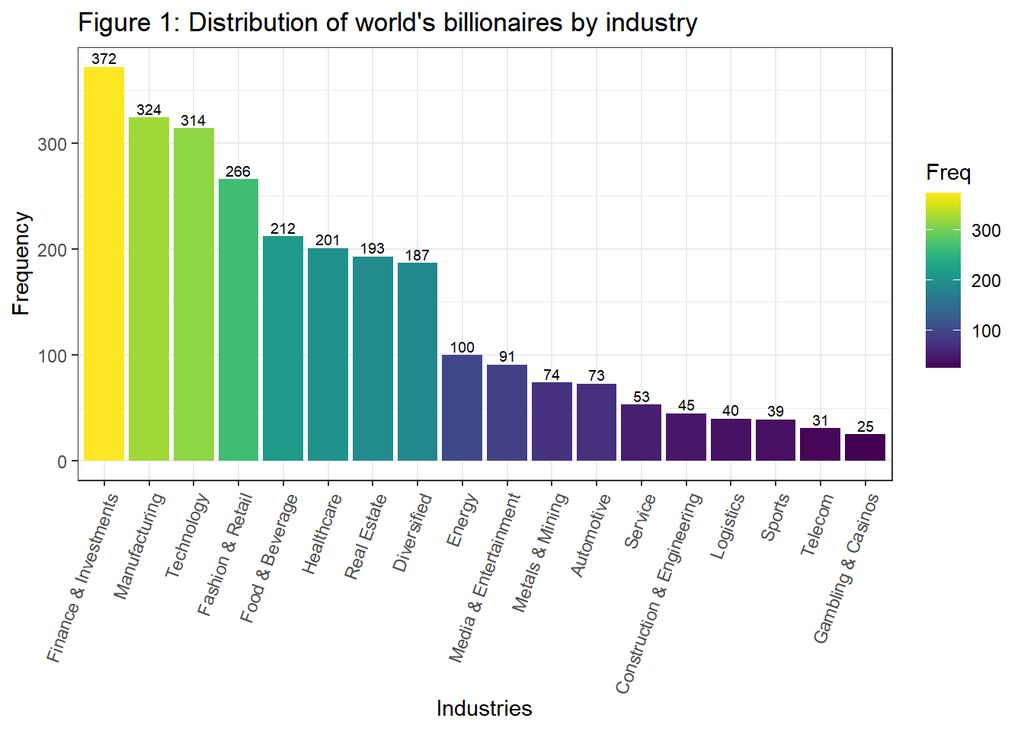

```r
factor_category <- factor(df_Billionaires$category)
category1 <- as.data.frame(table(factor_category))

pl_cat <- ggplot(category1, aes(x = reorder(factor_category, -Freq),
                                y = Freq)) +
  geom_bar(stat = 'identity', aes(fill = Freq)) +
  scale_fill_viridis() +     #from package "viridis"
  geom_text(aes(label= Freq), vjust=-0.3, size=2.5) +
  theme_bw() +
  labs(color = NULL,
       y = "Frequency",
       x = "Industries",
       title = "Figure 1: Distribution of world's billionaires by industry") +
  theme(strip.background = element_blank(),
        axis.text.x = element_text(angle = 70,
                                   hjust = 1))
pl_cat
```

### 1.2 By Gender

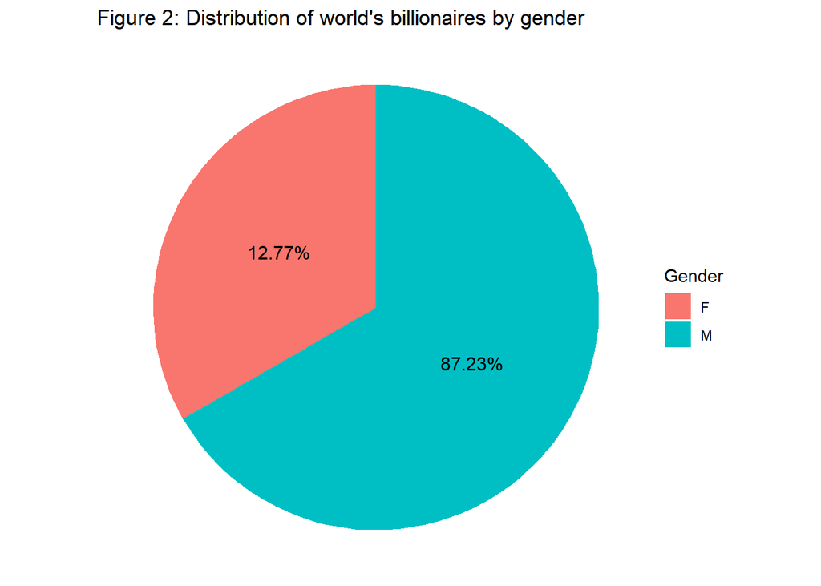

```r
factor_ges <- factor(df_Billionaires$gender)
ges <- as.data.frame(table(factor_ges)) %>%
  rename(Anzahl = Freq) %>%
  mutate(Anteil = Anzahl/2640) %>%
  mutate(Anteilp = scales::percent(Anteil, accuracy = 0.01))

plot_ges <- ggplot(ges, aes(x = "", y = Anteilp, fill = factor_ges)) +
  geom_bar(stat = 'identity', width = 0.6) +
  geom_text(aes(label = Anteilp),
            position = position_stack(vjust = 0.5), size= 4) +
  theme_void() +
  guides(fill = guide_legend(title = "Gender"))  +
  coord_polar("y", start=0) +
  labs(color = NULL,
       title = "Figure 2: Distribution of world's billionaires by gender")
plot_ges
```

The majority of the billionaires (87.23%) are male, whereas only 12.77% are female.

### 1.3 By Country

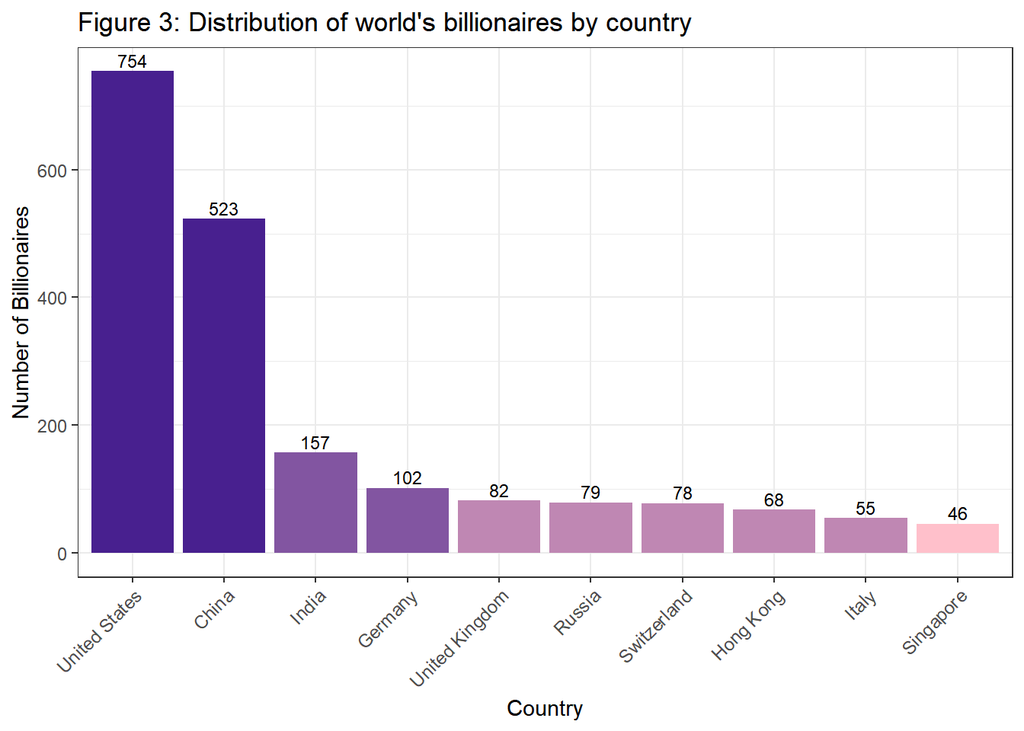

```r
factor_country <- factor(df_Billionaires$country)
country <- as.data.frame(table(factor_country))
country_sorted <- country[order(country$Freq),] %>%
  tail( n= 10L)

cols1 <- c( "pink",
            "#BF87B3","#BF87B3","#BF87B3","#BF87B3","#BF87B3",
            "#8255a1",
            "#8255a1",
            rgb(72/255, 32/255, 143/255),
            rgb(72/255, 32/255, 143/255))

plot_country <- ggplot(country_sorted, aes(x = reorder(factor_country, -Freq,
                                                       decreasing = FALSE),
                                           y = Freq)) +
  geom_bar(stat = 'identity', fill = cols1) +
  geom_text(aes(label= Freq), vjust=-0.3, size=3) +
  theme_bw() +
  labs(color = NULL,
       y = "Number of Billionaires",
       x = "Country",
       title = "Figure 3: Distribution of world's billionaires by country") +
 theme(strip.background = element_blank(),
        axis.text.x = element_text(angle = 45,
                                   hjust = 1, size = 9),
       axis.text.y = element_text(size = 9))
plot_country
```

The United States has the most billionaires, followed by China, India and Germany.

### 1.4 By Status

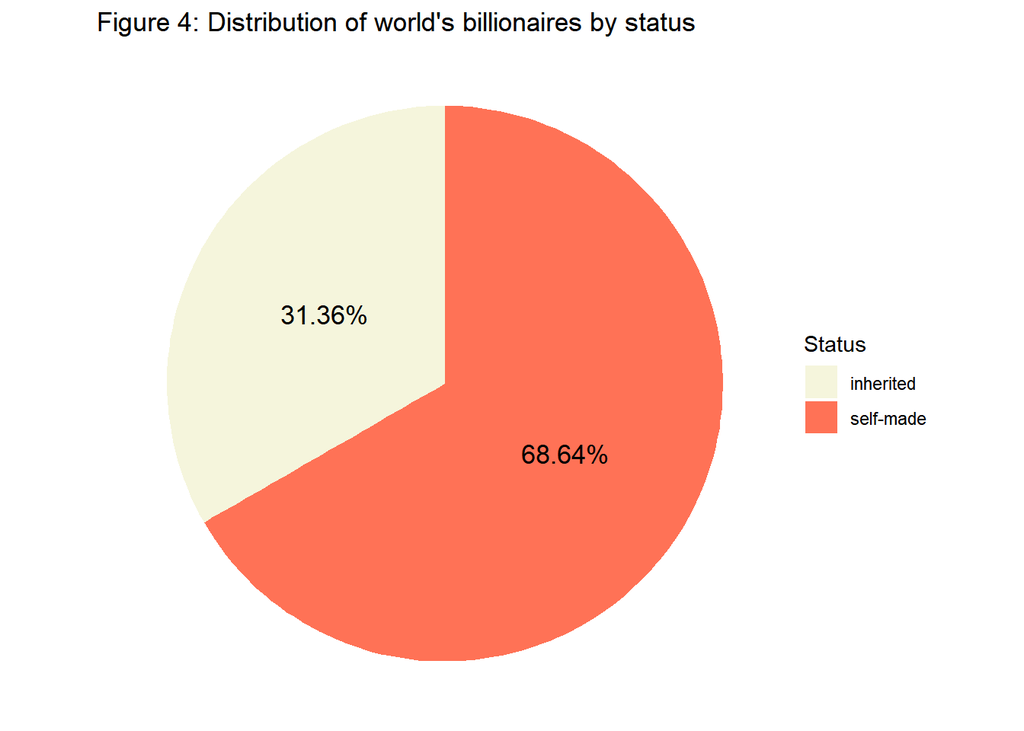

```r
factor_status <- factor(df_Billionaires$selfMade)
status <- as.data.frame(table(factor_status)) %>%
  mutate(Anteil = Freq/2640) %>%
  mutate(Anteilp = scales::percent(Anteil, accuracy = 0.01))

plot_status <- ggplot(status, aes(x = "", y = Anteilp, fill = factor_status)) +
  geom_bar(stat = 'identity') +
  theme_void() +
  geom_text(aes(label = Anteilp),
            position = position_stack(vjust = 0.5), size= 4.5) +
  guides(fill = guide_legend(title = "Status")) +
  scale_fill_manual(labels = c("inherited", "self-made"),
                    values=c("beige", "coral1")) +
  coord_polar("y", start=0) +
  labs(color = NULL,
       title = "Figure 4: Distribution of world's billionaires by status")
plot_status
```

The largest part (68.64%) of the billionaires are self-made, whereas the rest 31.36% are inherited.

### 1.5 By Age

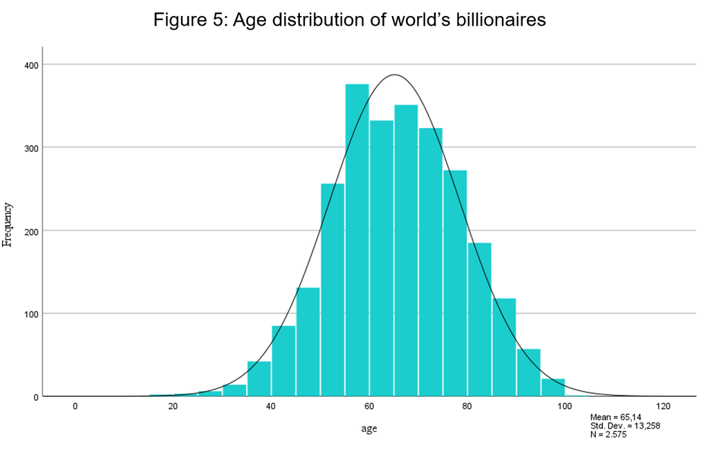

### 1.6 Top 10 richest

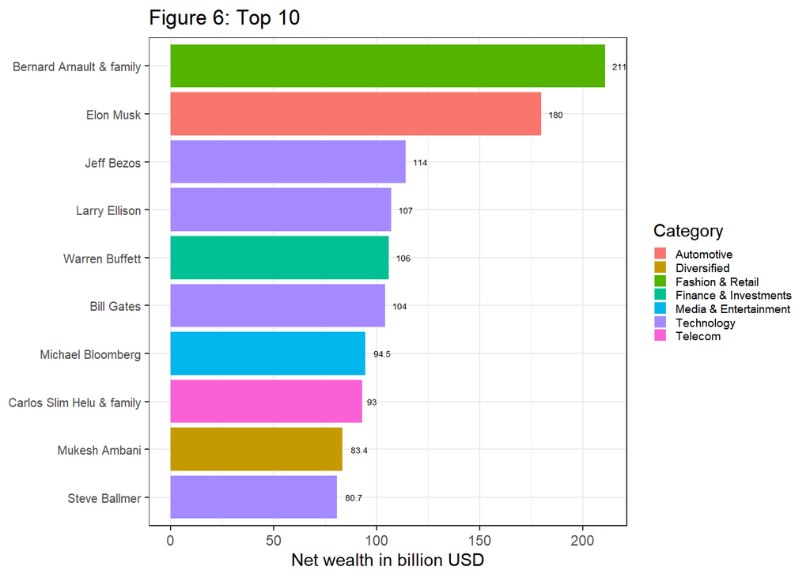

```r
top10 <- df_Billionaires %>%
  head(n = 10L)

plot_top10 <- ggplot(top10, aes(x = reorder(personName, finalWorth_bln),
                                y = finalWorth_bln, fill = category)) +
  geom_bar(stat = 'identity') +
  geom_text(aes(label = finalWorth_bln),hjust = -0.5, size = 1.8)  +
  guides(fill = guide_legend(title = "Category")) +
  theme_bw() +
  coord_flip() +
  labs(color = NULL,
       y = "Net wealth in billion USD",
       x = NULL,
       title = "Figure 6: Top 10") +
  theme(strip.background = element_blank(),
        axis.text.y = element_text(size = 7.5),
        legend.key.size = unit(0.3, 'cm'),
        legend.text = element_text(size = 7))
plot_top10
```

As of 04.04.2023, Bernard Arnault & family from the fashion & retail industry rank first among the world’s 10 wealthiest people with the highest net worth of $211 billion.  
Elon Musk is the world’s second wealthiest person whose net worth stems from the automotive industry.  
Technology is most populous sector in the top 10 since it has four billionaires named in the list including Jeff Bezos ($114 billion), Larry Ellison ($107 billion), Bill Gates ($104 billion) and Steve Ballmer ($80.7 billion).

## 2. Crosstabulations

### 2.1 Net Worth and Industries

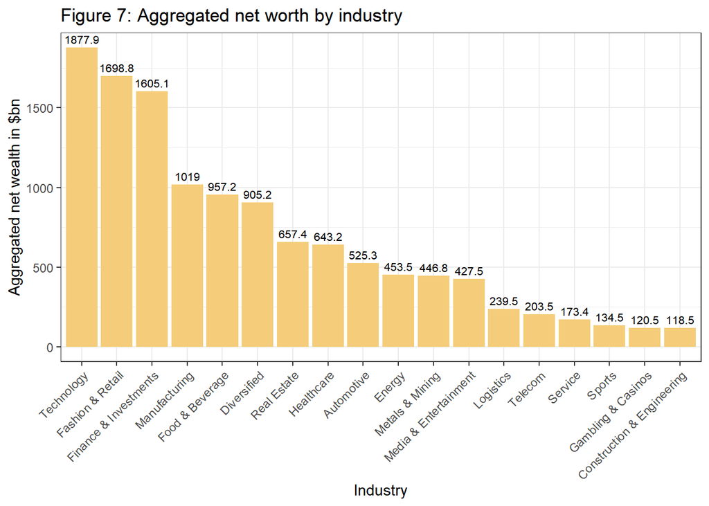

```r
netw_industry <- df_Billionaires %>%
  group_by(category) %>%
  summarise(summe = sum(finalWorth_bln)) %>%
  mutate(Pct = summe/sum(summe)) %>%
  mutate(Per = scales::percent(Pct, accuracy = 0.01))

netw_industry_sorted <- netw_industry[order(-netw_industry$summe),]

plot_netw_industry <- ggplot(netw_industry_sorted, aes(x = reorder(category, -summe, decreasing = FALSE), y = summe)) +
  geom_bar(stat = "identity", fill = "#F5CD7A") +
  geom_text(aes(label = summe), vjust = -0.5, size = 2.8) +
  theme_bw() +
  labs(y = "Aggregated net wealth in $bn",
       x = "Industry",
       title = "Figure 7: Aggregated net worth by industry") +
  theme(strip.background = element_blank(),
        axis.text.x = element_text(angle = 45,
                                   hjust = 1))
plot_netw_industry
```

Technology, Fashion & Retail, Finance & Investments, Manufacturing, and Food & Beverage represent the top five industries by aggregated net worth. This aligns with their high concentration of billionaires, as shown in Figure 1.

```r
df_anova <- df_Billionaires %>%
  group_by(industries) %>%
  summarize(min = min(finalWorth_bln),
            max = max(finalWorth_bln),
            median = median(finalWorth_bln),
            mean = mean(finalWorth_bln))
df_anova
```

| industries | min | max | median | mean |
| --- | --- | --- | --- | --- |
| Automotive | 1.0 | 180.0 | 2.60 | 7.195890 |
| Construction & Engineering | 1.0 | 13.7 | 2.10 | 2.633333 |
| Diversified | 1.0 | 83.4 | 2.30 | 4.840642 |
| Energy | 1.0 | 25.5 | 2.45 | 4.535000 |
| Fashion & Retail | 1.0 | 211.0 | 2.50 | 6.386466 |
| Finance & Investments | 1.0 | 106.0 | 2.60 | 4.314785 |
| Food & Beverage | 1.0 | 68.0 | 2.50 | 4.515094 |
| Gambling & Casinos | 1.0 | 35.0 | 2.80 | 4.820000 |
| Healthcare | 1.0 | 22.6 | 2.10 | 3.200000 |
| Logistics | 1.0 | 39.1 | 3.00 | 5.987500 |

[output cut: 8 more lines]

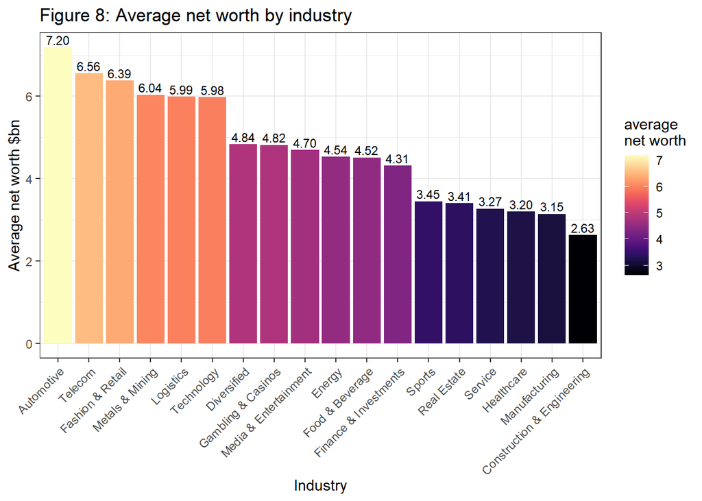

```r
plot_anova <- ggplot(df_anova, aes(x = reorder(industries,-mean,
                                               decreasing = FALSE), y = mean)) +
  geom_bar(stat = "identity",aes(fill = mean)) +
  scale_fill_viridis(option = "magma", name = paste0("average", "\n","net worth"))+
  theme_bw() +
  geom_text(aes(label = scales::number(mean, accuracy = 0.01)),
            vjust = -0.3, size = 3) +
  labs(y = "Average net worth $bn",
       x = "Industry",
       title = "Figure 8: Average net worth by industry") +
  theme(strip.background = element_blank(),
        axis.text.x = element_text(angle = 45,
                                   hjust = 1))

plot_anova
```

The automotive sector leads with the highest average net worth ($7.20 billion) per billionaire. This differs from the patterns seen in Figures 1 and 7 because average net worth depends on the ratio between total industry wealth and number of billionaires in each sector.

### 2.2 Industries and Age groups

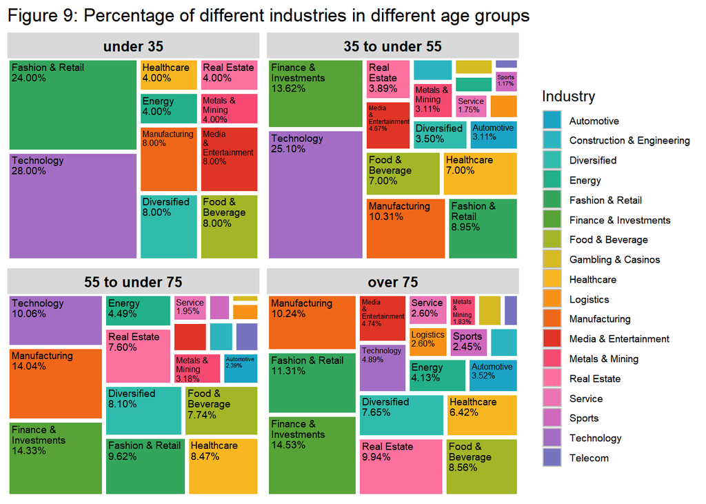

```r
age_groups <- ifelse(df_Billionaires$age < 35, "under 35",
                    ifelse(df_Billionaires$age < 55, "35 to under 55",
                           ifelse(df_Billionaires$age < 75, "55 to under 75",
                                  "over 75")))
df_Billionaires$agegroups <- age_groups
df_agegroups_industries <- as.data.frame(xtabs(~df_Billionaires$industries +
                                                 df_Billionaires$agegroups))
df_agegroups_industries1 <- df_agegroups_industries %>%
  group_by(df_Billionaires.agegroups, df_Billionaires.industries) %>%
  summarise(count = sum(Freq)) %>%
  mutate(per = count/sum(count)) %>%
  mutate(percent = scales::percent(per, accuracy = 0.01))

plot_treemap <- df_agegroups_industries1  %>%
  ggplot(aes(area = per, fill = df_Billionaires.industries,
             group = df_Billionaires.agegroups, subgroup = df_Billionaires.industries,
             label = paste0(df_Billionaires.industries, "\n", percent))) +
  geom_treemap() +
  facet_wrap(~factor(df_Billionaires.agegroups, c("under 35", "35 to under 55",
                                                  "55 to under 75", "over 75")))  +
  theme(strip.text = element_text(face = "bold", size = 10, color = "black"),
        legend.key.size = unit(0.5, 'cm'),
        legend.text = element_text(size = 7))+
  geom_treemap_text(grow = F, reflow = T, size = 7, colour = "black") +
  geom_treemap_subgroup_border(colour = "white") +
  scale_fill_tableau(palette = "Hue Circle") +
  guides(fill = guide_legend(title = "Industry")) +
  labs(title = "Figure 9: Percentage of different industries in different age groups")
plot_treemap
```

A clear age-related trend emerges in the technology sector, with billionaire representation steadily declining across age groups (28%, 25.10%, 10.06%, 4.89%). This suggests younger billionaires are significantly more likely to have built their wealth in technology.  
Conversely, the Finance & Investment sector shows an increasing presence with age (0%, 13.62%, 14.33%, 14.53%), indicating this industry tends to produce billionaires later in their careers.